# Aero_fit

Aero_Fit CaseStudy My intent and motivation to solve this case study is to become more skilled, aware, and creative in the way I observe the data. I would like to take this opportunity to infer as many understanding from the data as possible. This casestudy is of a company who designs the treadmills with 3 models and the types of users who use them and their details. There are 3 segments- 1- Entry level KP281 costing $1500 2- Mid level KP481 costing $1750 3- High level KP781 costing $2500 I have first tried to understand the data for its description and cleanliness to determine what type of cleaning is needed whether needed or not. According to the first operation on data it seems that there are in total 9 variables out of which, 3 are categorical and 6 are numerical 3 categorical vairables are- 1- Product type 2- Gender 3- Marital Status 6 Numerical variables are- 1- Age 2- Education 3- Usage (hours) 4- Fitness (1-5) 5- Income 6- Miles (ridden on the treadmill) There are in total 180 entries There are no NaN values in the data The diversity of the products are as follows- KP281 Entry level- 80 units KP481 Mid level- 60 units KP781 High level- 40 units There are in total 104 Males and 76 Females The marital status of them are 107 Partnered and 73 Single

```python
import numpy as np
import pandas as pd
import seaborn as sns
import matplotlib.pyplot as plt
from scipy.stats import norm
from scipy.stats import binom

!python -m wget  https://d2beiqkhq929f0.cloudfront.net/public_assets/assets/000/001/125/original/aerofit_treadmill.csv?1639992749 weight-height.csv
```

```
Saved under aerofit_treadmill (6).csv
```

```python
df=pd.read_csv("aerofit_treadmill.csv")
df
```

|  | Product | Age | Gender | Education | MaritalStatus | Usage | Fitness | Income | Miles |
| --- | --- | --- | --- | --- | --- | --- | --- | --- | --- |
| 0 | KP281 | 18 | Male | 14 | Single | 3 | 4 | 29562 | 112 |
| 1 | KP281 | 19 | Male | 15 | Single | 2 | 3 | 31836 | 75 |
| 2 | KP281 | 19 | Female | 14 | Partnered | 4 | 3 | 30699 | 66 |
| 3 | KP281 | 19 | Male | 12 | Single | 3 | 3 | 32973 | 85 |
| 4 | KP281 | 20 | Male | 13 | Partnered | 4 | 2 | 35247 | 47 |
| ... | ... | ... | ... | ... | ... | ... | ... | ... | ... |
| 175 | KP781 | 40 | Male | 21 | Single | 6 | 5 | 83416 | 200 |
| 176 | KP781 | 42 | Male | 18 | Single | 5 | 4 | 89641 | 200 |
| 177 | KP781 | 45 | Male | 16 | Single | 5 | 5 | 90886 | 160 |
| 178 | KP781 | 47 | Male | 18 | Partnered | 4 | 5 | 104581 | 120 |
| 179 | KP781 | 48 | Male | 18 | Partnered | 4 | 5 | 95508 | 180 |

180 rows × 9 columns

```python
#Checking the info of df
df.info()

'''There are 9 variables '''
```

```
<class 'pandas.core.frame.DataFrame'>
RangeIndex: 180 entries, 0 to 179
Data columns (total 9 columns):
 #   Column         Non-Null Count  Dtype
---  ------         --------------  -----
 0   Product        180 non-null    object
 1   Age            180 non-null    int64
 2   Gender         180 non-null    object
 3   Education      180 non-null    int64
 4   MaritalStatus  180 non-null    object
 5   Usage          180 non-null    int64
 6   Fitness        180 non-null    int64
 7   Income         180 non-null    int64
 8   Miles          180 non-null    int64
dtypes: int64(6), object(3)
memory usage: 12.8+ KB
```

```
'There are 9 variables '
```

```python
#Checking the Shape of data
df.shape
```

```
(180, 9)
```

```python
#Checking for NaN values in the DataFrame
df.isna().sum().sum()
```

```
0
```

```python
#Calculating Mean, Statndard Deviation, Variance, Max, Min values of Age
print('Mean= ' ,np.mean(df['Age']))
print('Standard deviation= ', np.std(df['Age']))
print('Variance= ',np.var(df['Age']))
print('Max=', np.max(df['Age']))
print('Max=', np.min(df['Age']))
```

```
Mean=  28.788888888888888
Standard deviation=  6.924183777720976
Variance=  47.94432098765432
Max= 50
Max= 18
```

```python
# Counting the number of unique products
pd.value_counts(df['Product'])

#This metric can show us that there are 3 different types of products in the dataset
```

```
Product
KP281    80
KP481    60
KP781    40
Name: count, dtype: int64
```

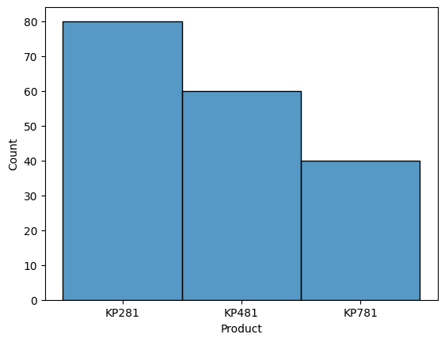

```python
#Checking the engagements with the various products graphically
sns.histplot(df['Product'])

#Seems like the KP281, KP481, KP781 are used in a decreasing order of 4:3 ratio.
```

```python
#Chekcing for the gender ratio
pd.value_counts(df['Gender'])

#This metric shows us that what gender uses the device more.
```

```
Gender
Male      104
Female     76
Name: count, dtype: int64
```

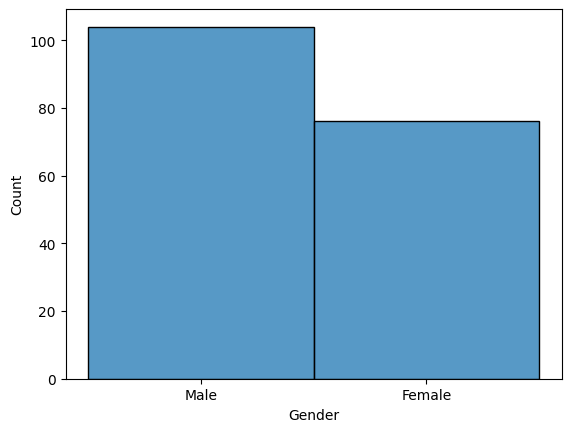

```python
#Checing the gender info graphically.
sns.histplot(df['Gender'])

#Same trend of 4:3 is being followed here.
```

```python
#Checking for the Single vs Partnered
pd.value_counts(df['MaritalStatus'])
```

```
MaritalStatus
Partnered    107
Single        73
Name: count, dtype: int64
```

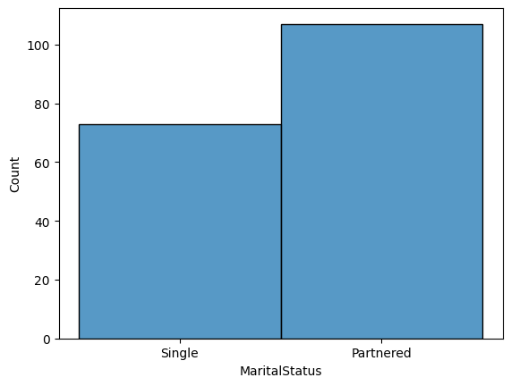

```python
#Checing the gender info graphically.
sns.histplot(df['MaritalStatus'])

#Same trend of 4:3 is being followed here.
```

```python
#Classifing the database into their own dataframes
df_entry=df[df['Product']=='KP281']
df_mid=df[df['Product']=='KP481']
df_adv=df[df['Product']=='KP781']
```

```python
#Seeing the min, max, mean values of the various parameters. And also the Standard deviation and the percentiles of it.
print("\033[1mEntry Level\033[0m\n",df_entry.describe(),"\n")
print("\033[1mMid Level\033[0m\n",df_mid.describe(),"\n")
print("\033[1mAdv Level\033[0m\n",df_adv.describe(),"\n")
```

```
Entry Level
              Age  Education      Usage   Fitness       Income       Miles
count  80.000000  80.000000  80.000000  80.00000     80.00000   80.000000
mean   28.550000  15.037500   3.087500   2.96250  46418.02500   82.787500
std     7.221452   1.216383   0.782624   0.66454   9075.78319   28.874102
min    18.000000  12.000000   2.000000   1.00000  29562.00000   38.000000
25%    23.000000  14.000000   3.000000   3.00000  38658.00000   66.000000
50%    26.000000  16.000000   3.000000   3.00000  46617.00000   85.000000
75%    33.000000  16.000000   4.000000   3.00000  53439.00000   94.000000
max    50.000000  18.000000   5.000000   5.00000  68220.00000  188.000000

Mid Level
              Age  Education      Usage   Fitness        Income       Miles
count  60.000000  60.000000  60.000000  60.00000     60.000000   60.000000
mean   28.900000  15.116667   3.066667   2.90000  48973.650000   87.933333
std     6.645248   1.222552   0.799717   0.62977   8653.989388   33.263135
min    19.000000  12.000000   2.000000   1.00000  31836.000000   21.000000
25%    24.000000  14.000000   3.000000   3.00000  44911.500000   64.000000
50%    26.000000  16.000000   3.000000   3.00000  49459.500000   85.000000
75%    33.250000  16.000000   3.250000   3.00000  53439.000000  106.000000
max    48.000000  18.000000   5.000000   4.00000  67083.000000  212.000000

Adv Level
              Age  Education      Usage    Fitness        Income       Miles
count  40.000000  40.000000  40.000000  40.000000      40.00000   40.000000
mean   29.100000  17.325000   4.775000   4.625000   75441.57500  166.900000
std     6.971738   1.639066   0.946993   0.667467   18505.83672   60.066544
min    22.000000  14.000000   3.000000   3.000000   48556.00000   80.000000
25%    24.750000  16.000000   4.000000   4.000000   58204.75000  120.000000
50%    27.000000  18.000000   5.000000   5.000000   76568.50000  160.000000
75%    30.250000  18.000000   5.000000   5.000000   90886.00000  200.000000
max    48.000000  21.000000   7.000000   5.000000  104581.00000  360.000000
```